## Design and Analysis of Experiments for Simulation

# Design and Analysis of Experiments for Simulation

Steve Gillespie & John King

As of 4 March 2020

## Introduction

This is an information presentation on the course:

“Design and Analysis of Experiments for Simulation.”

At the end, viewers should be able to make an informed decision on committing time to taking the course.

**Agenda:**

- About
- Why Design of Experiments (DOE)
- Course Information

## About

- The course was developed by TRAC Fort Leavenworth.
  - MAJ Steve Gillespie & MAJ John King.
  - Assistance and review from the [Data Science Center of Education](https://dscoe.org).
- The course is intended to develop capable practioners of DOE for simulation.
- The course is built specifically for analysts at TRAC Fort Leavenworth , Wargaming and Simulation Directorate; however, it is broadly applicable to any analyst needing to understand and employ DOE.

## Why Design of Experiments?

> “All experiments are designed experiments. The important issue is whether they are well designed or not.”

Douglas C. Montgomery  
*Design and Analysis of Experiments*

- DOE is good statistical practice.
- DOE ensures efficient use of resources.
- DOE (and associated analysis) is relevant to AFC missions (e.g., requirements engineering, portfolio analysis).

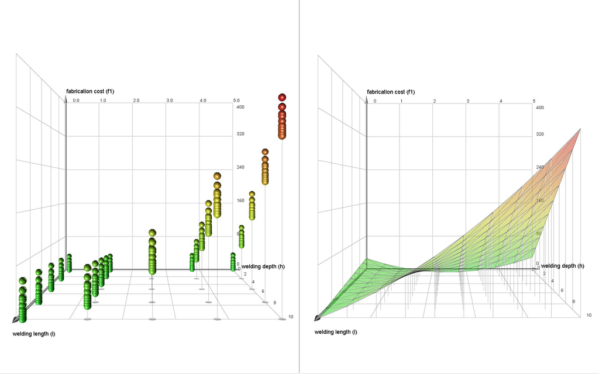

## Course Information

At the end of the course, an analyst should be able to design and analyze simulation output to inform a large variety of study questions in a statistically valid manner.

- Course Sections :
  - R Fundamentals.
  - Statistics Review.
  - Foundations of DOE.
  - Foundations of Regression and Modeling.
  - Applications of DOE.
  - Advanced Topics.
  - Optional Advanced Topics.
- Each of these sections is supported by a variety of resources.
- The course can be completed individually or as a group.
- TRAC Ft. Leavenworth will lead a local class.
  - Start on 01APR2020 .
  - Meet every Wed. for a 3 x hour lab.
  - The learning model is: Analysts work through the weekly assignment and use the lab to answer questions and collaborate.

## Course Requirements

- Time :
  - Approximately 10 hours per week.
  - 6-9 months.
- Knowledge:
  - Fundamental mathematics & statistics.
  - Desire to learn.
- Resources:
  - Computer with internet connection. The course is hosted at: https://doe.dscoe.org.
  - R programming environment. We are using www.matrixds.com (free) as it largely eliminates challenges associated with government computer restrictions.

# Additional Course Information

## DOE for Simulation Schedule (TRAC Ft. Leavenworth)

This schedule is approximate. The goal is that analysts taking the course will be able to do a foundational design and analysis by mid-August.

| Lab.Number | Day | Time | Location | Topic |
| --- | --- | --- | --- | --- |
| 1 | 01 Apr 20 | 9:00-12:00 | CARL Library Rm. 131 | Course Intro &amp; Intro to R |
| 2 | 08 Apr 20 | 9:00-12:00 | CARL Library Rm. 131 | Intro to R I |
| 3 | 15 Apr 20 | 9:00-12:00 | CARL Library Rm. 131 | Intro to R II |
| 4 | 22 Apr 20 | 9:00-12:00 | CARL Library Rm. 131 | Statistics Review - Descriptive Statistics |
| 5 | 29 Apr 20 | 9:00-12:00 | CARL Library Rm. 131 | Statistics Review - Statistical Concepts |
| 6 | 06 May 20 | 9:00-12:00 | CARL Library Rm. 131 | Statistics Review - Statistical Inference |
| 7 | 13 May 20 | 9:00-12:00 | CARL Library Rm. 131 | Statistics Review - ANOVA I |
| 8 | 20 May 20 | 9:00-12:00 | CARL Library Rm. 131 | Statistics Review - ANOVA II |
| 9 | 27 May 20 | 9:00-12:00 | CARL Library Rm. 131 | Fundamentals of DOE I |
| 10 | 03 Jun 20 | 9:00-12:00 | CARL Library Rm. 131 | Fundamentals of DOE II |

[output cut: 28 more lines]

## DOE For Simulation Sections

| Number | Name |
| --- | --- |
| 1 | R Fundamentals |
| 2 | Statistics Review |
| 3 | Fundamentals of Design of Experiments (DOE) |
| 4 | Basic Regression |
| 5 | Applications |
| 6 | Advanced Topics |
| 7 | Optional Advanced Topics |

## Lessons

Note that these are currently under development and will change.

| Section # | Section Name | Lesson Number | Lesson_Name | Lesson Description |
| --- | --- | --- | --- | --- |
| 1 | R Fundamentals | 1 | Introduction to R | Introduce the programming language R, standard data types, basic functionality, and R resources. |
| 1 | R Fundamentals | 2 | R for Data Science | Introduce R concepts for data science. |
| 1 | R Fundamentals | 3 | Markdown | Introduce the concept of R markdown for analysis visualization. |
| 2 | Statistics Review | 1 | Descriptive Statistics | Review foundational descriptive statistics and methods for conducting descriptive statistics in R. |
| 2 | Statistics Review | 2 | Basic Statistical Concepts |  |
| 2 | Statistics Review | 4 | ANOVA |  |
| 2 | Statistics Review | 3 | Statistical Inference |  |
| 3 | Fundamentals of Design of Experiments (DOE) | 1 | Intro to DOE | Montgomery Chapter 1 |
| 3 | Fundamentals of Design of Experiments (DOE) | 2 | Full Factorial Design |  |
| 3 | Fundamentals of Design of Experiments (DOE) | 3 | Fractional Factorial Design |  |

[output cut: 23 more lines]

## Objectives

Note that these are currently under development and will change.

| Section Name | Lesson # | Lesson Name | Objective Name |
| --- | --- | --- | --- |
| R Fundamentals | 1 | Introduction to R | Familiarization with R Studio. |
| R Fundamentals | 1 | Introduction to R | Create and manipulate common data structures |
| R Fundamentals | 1 | Introduction to R | Create and call custom functions. |
| R Fundamentals | 1 | Introduction to R | Apply flow control methods (if-else, for loops, while loops). |
| R Fundamentals | 1 | Introduction to R | Visualize data with base R and ggplot. |
| R Fundamentals | 1 | Introduction to R | Understand how to wrangle data with tidyverse. |
| Statistics Review | 1 | Descriptive Statistics | Describe, produce (using R), and interpret data variability graphically (histogram &amp; boxplot). |
| Statistics Review | 1 | Descriptive Statistics | Describe, produce (using R), and interpret discrete and continuous probability distributions (Discrete Uniform, Bernoulli, Binomial, Normal, Uniform, Poisson). |
| Statistics Review | 1 | Descriptive Statistics | Describe, produce (using R), and interpret Mean, Variance (&amp; Standard Deviation), and Expected Value. |
| Statistics Review | 2 | Basic Statistical Concepts | Understand and apply the following terms: "Random Sample," 'Statistic", "Estimator", "Degrees of Freedom" |

[output cut: 39 more lines]